# COVID 19 R Markdown

# Introduce

Data from the [Johns Hopkins GitHub site](https://github.com/CSSEGISandData/COVID-19/tree/master/csse_covid_19_data/csse_covid_19_time_series) was used. After processing and merging the global cases and global deaths data, 330,327 records were obtained, with five features extracted: Province_State, Country_Region, date, cases, and deaths, covering the period from January 22, 2020, to March 9, 2023.

For the US data, after processing and merging US cases and US deaths, 3,819,906 records were obtained, with seven features extracted for analysis: Admin2, Province_State, Country_Region, date, cases, population, and deaths.

After data processing, linear regression was used to explore the relationship between cases per thousand and deaths per thousand.

### Libraries

```r
library(stringr)
library(tidyverse)
```

```r
library(lubridate)
library(ggplot2)
library(scales)
library(dplyr)
```

# Data Anaylsis

### Import Data

```r
url_in <- "https://raw.githubusercontent.com/CSSEGISandData/COVID-19/master/csse_covid_19_data/csse_covid_19_time_series/"
file_name <- c("time_series_covid19_confirmed_US.csv",
               "time_series_covid19_confirmed_global.csv",
               "time_series_covid19_deaths_US.csv",
               "time_series_covid19_deaths_global.csv")
urls <- str_c(url_in, file_name)
urls
```

```
## [1] "https://raw.githubusercontent.com/CSSEGISandData/COVID-19/master/csse_covid_19_data/csse_covid_19_time_series/time_series_covid19_confirmed_US.csv"
## [2] "https://raw.githubusercontent.com/CSSEGISandData/COVID-19/master/csse_covid_19_data/csse_covid_19_time_series/time_series_covid19_confirmed_global.csv"
## [3] "https://raw.githubusercontent.com/CSSEGISandData/COVID-19/master/csse_covid_19_data/csse_covid_19_time_series/time_series_covid19_deaths_US.csv"
## [4] "https://raw.githubusercontent.com/CSSEGISandData/COVID-19/master/csse_covid_19_data/csse_covid_19_time_series/time_series_covid19_deaths_global.csv"
```

```r
us_cases <- read.csv(urls[1])
global_cases <- read.csv(urls[2])
us_deaths <- read.csv(urls[3])
global_deaths <- read.csv(urls[4])
```

## Global Data

### Global Cases

```r
global_cases <- global_cases %>%
                pivot_longer(cols = starts_with('X'),
                             names_to = 'date',
                             values_to = 'cases') %>%
                mutate(date = as.Date(date, format = "X%m.%d.%y")) %>%
                rename(Province_State = 'Province.State',
                       Country_Region = 'Country.Region') %>%
                select(-c(Lat, Long))
global_cases
```

```
## # A tibble: 330,327 × 4
##    Province_State Country_Region date       cases
##    <chr>          <chr>          <date>     <int>
##  1 ""             Afghanistan    2020-01-22     0
##  2 ""             Afghanistan    2020-01-23     0
##  3 ""             Afghanistan    2020-01-24     0
##  4 ""             Afghanistan    2020-01-25     0
##  5 ""             Afghanistan    2020-01-26     0
##  6 ""             Afghanistan    2020-01-27     0
##  7 ""             Afghanistan    2020-01-28     0
##  8 ""             Afghanistan    2020-01-29     0
##  9 ""             Afghanistan    2020-01-30     0
## 10 ""             Afghanistan    2020-01-31     0
## # ℹ 330,317 more rows
```

### Global Deaths

```r
global_deaths <- global_deaths %>%
                pivot_longer(cols = starts_with('X'),
                             names_to = 'date',
                             values_to = 'cases') %>%
                mutate(date = as.Date(date, format = "X%m.%d.%y")) %>%
                rename(Province_State = 'Province.State',
                       Country_Region = 'Country.Region',
                       deaths = 'cases') %>%
                select(-c(Lat, Long))
global_deaths
```

```
## # A tibble: 330,327 × 4
##    Province_State Country_Region date       deaths
##    <chr>          <chr>          <date>      <int>
##  1 ""             Afghanistan    2020-01-22      0
##  2 ""             Afghanistan    2020-01-23      0
##  3 ""             Afghanistan    2020-01-24      0
##  4 ""             Afghanistan    2020-01-25      0
##  5 ""             Afghanistan    2020-01-26      0
##  6 ""             Afghanistan    2020-01-27      0
##  7 ""             Afghanistan    2020-01-28      0
##  8 ""             Afghanistan    2020-01-29      0
##  9 ""             Afghanistan    2020-01-30      0
## 10 ""             Afghanistan    2020-01-31      0
## # ℹ 330,317 more rows
```

### Global

```r
global <- global_cases %>%
          full_join(global_deaths,
                    by=c('Province_State', 'Country_Region', 'date'))
global
```

```
## # A tibble: 330,327 × 5
##    Province_State Country_Region date       cases deaths
##    <chr>          <chr>          <date>     <int>  <int>
##  1 ""             Afghanistan    2020-01-22     0      0
##  2 ""             Afghanistan    2020-01-23     0      0
##  3 ""             Afghanistan    2020-01-24     0      0
##  4 ""             Afghanistan    2020-01-25     0      0
##  5 ""             Afghanistan    2020-01-26     0      0
##  6 ""             Afghanistan    2020-01-27     0      0
##  7 ""             Afghanistan    2020-01-28     0      0
##  8 ""             Afghanistan    2020-01-29     0      0
##  9 ""             Afghanistan    2020-01-30     0      0
## 10 ""             Afghanistan    2020-01-31     0      0
## # ℹ 330,317 more rows
```

```r
summary(global)
```

```
##  Province_State     Country_Region          date                cases
##  Length:330327      Length:330327      Min.   :2020-01-22   Min.   :        0
##  Class :character   Class :character   1st Qu.:2020-11-02   1st Qu.:      680
##  Mode  :character   Mode  :character   Median :2021-08-15   Median :    14429
##                                        Mean   :2021-08-15   Mean   :   959384
##                                        3rd Qu.:2022-05-28   3rd Qu.:   228517
##                                        Max.   :2023-03-09   Max.   :103802702
##      deaths
##  Min.   :      0
##  1st Qu.:      3
##  Median :    150
##  Mean   :  13380
##  3rd Qu.:   3032
##  Max.   :1123836
```

```r
# cols <- c("Province_State", "Country_Region")
# for (col in cols){
#   cat('Counts for each category in column:', col, '\n')
#   print(table(global[[col]]))
#   cat('\n')
# }

unique(global$Country_Region)
```

```
##   [1] "Afghanistan"                      "Albania"
##   [3] "Algeria"                          "Andorra"
##   [5] "Angola"                           "Antarctica"
##   [7] "Antigua and Barbuda"              "Argentina"
##   [9] "Armenia"                          "Australia"
##  [11] "Austria"                          "Azerbaijan"
##  [13] "Bahamas"                          "Bahrain"
##  [15] "Bangladesh"                       "Barbados"
##  [17] "Belarus"                          "Belgium"
##  [19] "Belize"                           "Benin"
##  [21] "Bhutan"                           "Bolivia"
##  [23] "Bosnia and Herzegovina"           "Botswana"
##  [25] "Brazil"                           "Brunei"
##  [27] "Bulgaria"                         "Burkina Faso"
##  [29] "Burma"                            "Burundi"
```

[output cut: 86 more lines]

```r
unique(global$Province_State)
```

```
##  [1] ""
##  [2] "Australian Capital Territory"
##  [3] "New South Wales"
##  [4] "Northern Territory"
##  [5] "Queensland"
##  [6] "South Australia"
##  [7] "Tasmania"
##  [8] "Victoria"
##  [9] "Western Australia"
## [10] "Alberta"
## [11] "British Columbia"
## [12] "Diamond Princess"
## [13] "Grand Princess"
## [14] "Manitoba"
## [15] "New Brunswick"
```

[output cut: 77 more lines]

### Global Totals

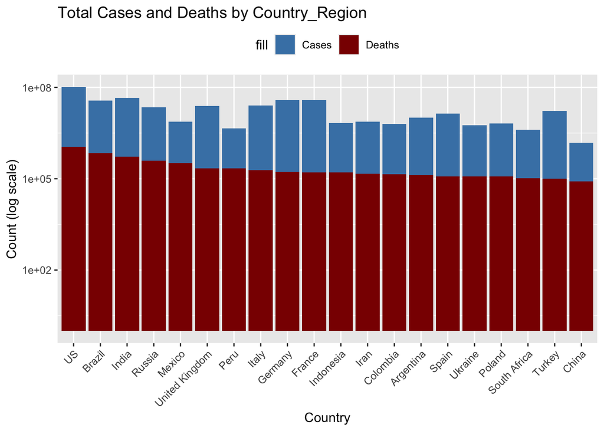

```r
global_totals <- global %>%
                 group_by(Country_Region) %>%
                 filter(date == max(date)) %>%
                 mutate(death_perc = 100 * deaths / cases) %>%
                 ungroup()
top_20_countries <- global_totals %>%
                    arrange(desc(deaths)) %>%
                    head(20)

ggplot(top_20_countries, aes(x = reorder(Country_Region, -deaths))) +
  geom_bar(aes(y = cases, fill = "Cases"), stat = "identity", position = "dodge") +
  geom_bar(aes(y = deaths, fill = "Deaths"), stat = "identity", position = "dodge") +
  scale_y_log10() +
  labs(title = "Total Cases and Deaths by Country_Region",
       x = "Country",
       y = "Count (log scale)") +
  scale_fill_manual(values = c("Cases" = "steelblue", "Deaths" = "darkred")) +
  theme(legend.position = 'top', axis.text.x = element_text(angle = 45, hjust = 1))
```

Ranking of countries with the highest total deaths: US, Brazil, India, Russia, Mexico, UK…

## US Data

### US Cases

```r
us_cases <- us_cases %>%
            pivot_longer(cols = starts_with('X'),
                         names_to = 'date',
                         values_to = 'cases') %>%
            mutate(date = as.Date(date, format = "X%m.%d.%y")) %>%
            select(-c(Lat, Long_, UID, iso2,  iso3, code3, FIPS, Combined_Key))
us_cases
```

```
## # A tibble: 3,819,906 × 5
##    Admin2  Province_State Country_Region date       cases
##    <chr>   <chr>          <chr>          <date>     <int>
##  1 Autauga Alabama        US             2020-01-22     0
##  2 Autauga Alabama        US             2020-01-23     0
##  3 Autauga Alabama        US             2020-01-24     0
##  4 Autauga Alabama        US             2020-01-25     0
##  5 Autauga Alabama        US             2020-01-26     0
##  6 Autauga Alabama        US             2020-01-27     0
##  7 Autauga Alabama        US             2020-01-28     0
##  8 Autauga Alabama        US             2020-01-29     0
##  9 Autauga Alabama        US             2020-01-30     0
## 10 Autauga Alabama        US             2020-01-31     0
## # ℹ 3,819,896 more rows
```

### US Deaths

```r
us_deaths <- us_deaths %>%
            pivot_longer(cols = starts_with('X'),
                         names_to = 'date',
                         values_to = 'cases') %>%
            mutate(date = as.Date(date, format = "X%m.%d.%y")) %>%
            rename(deaths = 'cases') %>%
            select(-c(Lat, Long_, UID, iso2,  iso3, code3, FIPS, Combined_Key))
us_deaths
```

```
## # A tibble: 3,819,906 × 6
##    Admin2  Province_State Country_Region Population date       deaths
##    <chr>   <chr>          <chr>               <int> <date>      <int>
##  1 Autauga Alabama        US                  55869 2020-01-22      0
##  2 Autauga Alabama        US                  55869 2020-01-23      0
##  3 Autauga Alabama        US                  55869 2020-01-24      0
##  4 Autauga Alabama        US                  55869 2020-01-25      0
##  5 Autauga Alabama        US                  55869 2020-01-26      0
##  6 Autauga Alabama        US                  55869 2020-01-27      0
##  7 Autauga Alabama        US                  55869 2020-01-28      0
##  8 Autauga Alabama        US                  55869 2020-01-29      0
##  9 Autauga Alabama        US                  55869 2020-01-30      0
## 10 Autauga Alabama        US                  55869 2020-01-31      0
## # ℹ 3,819,896 more rows
```

### US

```r
us <- us_cases %>%
      full_join(us_deaths,
                by=c('Province_State', 'Country_Region', 'Admin2', 'date')) %>%
      filter(!is.na(cases) & !is.na(deaths))
us
```

```
## # A tibble: 3,819,906 × 7
##    Admin2  Province_State Country_Region date       cases Population deaths
##    <chr>   <chr>          <chr>          <date>     <int>      <int>  <int>
##  1 Autauga Alabama        US             2020-01-22     0      55869      0
##  2 Autauga Alabama        US             2020-01-23     0      55869      0
##  3 Autauga Alabama        US             2020-01-24     0      55869      0
##  4 Autauga Alabama        US             2020-01-25     0      55869      0
##  5 Autauga Alabama        US             2020-01-26     0      55869      0
##  6 Autauga Alabama        US             2020-01-27     0      55869      0
##  7 Autauga Alabama        US             2020-01-28     0      55869      0
##  8 Autauga Alabama        US             2020-01-29     0      55869      0
##  9 Autauga Alabama        US             2020-01-30     0      55869      0
## 10 Autauga Alabama        US             2020-01-31     0      55869      0
## # ℹ 3,819,896 more rows
```

```r
summary(us)
```

```
##     Admin2          Province_State     Country_Region          date
##  Length:3819906     Length:3819906     Length:3819906     Min.   :2020-01-22
##  Class :character   Class :character   Class :character   1st Qu.:2020-11-02
##  Mode  :character   Mode  :character   Mode  :character   Median :2021-08-15
##                                                           Mean   :2021-08-15
##                                                           3rd Qu.:2022-05-28
##                                                           Max.   :2023-03-09
##      cases           Population           deaths
##  Min.   :  -3073   Min.   :       0   Min.   :  -82.0
##  1st Qu.:    330   1st Qu.:    9917   1st Qu.:    4.0
##  Median :   2272   Median :   24892   Median :   37.0
##  Mean   :  14088   Mean   :   99604   Mean   :  186.9
##  3rd Qu.:   8159   3rd Qu.:   64979   3rd Qu.:  122.0
##  Max.   :3710586   Max.   :10039107   Max.   :35545.0
```

```r
neg_rows <- us %>%
            filter(cases<0 | deaths<0)

# rows with cases or deaths < 0
print(neg_rows)
```

```
## # A tibble: 3 × 7
##   Admin2     Province_State Country_Region date       cases Population deaths
##   <chr>      <chr>          <chr>          <date>     <int>      <int>  <int>
## 1 Unassigned North Carolina US             2022-11-09   -34          0     -6
## 2 Unassigned South Carolina US             2022-05-05 -3073          0    -82
## 3 Unassigned South Carolina US             2022-05-06 -3073          0    -82
```

```r
us <- us %>%
      filter(cases >=0, deaths>=0)

summary(us)
```

```
##     Admin2          Province_State     Country_Region          date
##  Length:3819903     Length:3819903     Length:3819903     Min.   :2020-01-22
##  Class :character   Class :character   Class :character   1st Qu.:2020-11-02
##  Mode  :character   Mode  :character   Mode  :character   Median :2021-08-15
##                                                           Mean   :2021-08-14
##                                                           3rd Qu.:2022-05-28
##                                                           Max.   :2023-03-09
##      cases           Population           deaths
##  Min.   :      0   Min.   :       0   Min.   :    0.0
##  1st Qu.:    330   1st Qu.:    9917   1st Qu.:    4.0
##  Median :   2272   Median :   24909   Median :   37.0
##  Mean   :  14088   Mean   :   99604   Mean   :  186.9
##  3rd Qu.:   8159   3rd Qu.:   64979   3rd Qu.:  122.0
##  Max.   :3710586   Max.   :10039107   Max.   :35545.0
```

Three records have negative values for cases and deaths, which are likely input errors. Since there are only three recoreds, I have removed them.

### US by State

```r
us_by_state <- us %>%
              group_by(Province_State, Country_Region, date) %>%
              summarize(cases = sum(cases),
                        deaths = sum(deaths),
                        population = sum(Population)) %>%
              mutate(deaths_per_mill = deaths * 1000000 / population) %>%
              select(Province_State, Country_Region, date, cases, deaths, deaths_per_mill, population) %>%
              ungroup() %>%
              arrange(Country_Region, Province_State, date) %>%
              mutate(new_cases = cases - lag(cases),
                     new_deaths = deaths - lag(deaths))
us_by_state
```

```
## # A tibble: 66,294 × 9
##    Province_State Country_Region date       cases deaths deaths_per_mill
##    <chr>          <chr>          <date>     <int>  <int>           <dbl>
##  1 Alabama        US             2020-01-22     0      0               0
##  2 Alabama        US             2020-01-23     0      0               0
##  3 Alabama        US             2020-01-24     0      0               0
##  4 Alabama        US             2020-01-25     0      0               0
##  5 Alabama        US             2020-01-26     0      0               0
##  6 Alabama        US             2020-01-27     0      0               0
##  7 Alabama        US             2020-01-28     0      0               0
##  8 Alabama        US             2020-01-29     0      0               0
##  9 Alabama        US             2020-01-30     0      0               0
## 10 Alabama        US             2020-01-31     0      0               0
## # ℹ 66,284 more rows
## # ℹ 3 more variables: population <int>, new_cases <int>, new_deaths <int>
```

```r
tail(us_by_state)
```

```
## # A tibble: 6 × 9
##   Province_State Country_Region date        cases deaths deaths_per_mill
##   <chr>          <chr>          <date>      <int>  <int>           <dbl>
## 1 Wyoming        US             2023-03-04 185159   2002           3459.
## 2 Wyoming        US             2023-03-05 185159   2002           3459.
## 3 Wyoming        US             2023-03-06 185159   2002           3459.
## 4 Wyoming        US             2023-03-07 185385   2004           3463.
## 5 Wyoming        US             2023-03-08 185385   2004           3463.
## 6 Wyoming        US             2023-03-09 185385   2004           3463.
## # ℹ 3 more variables: population <int>, new_cases <int>, new_deaths <int>
```

```r
unique(us$Country_Region)
```

```
## [1] "US"
```

```r
state_sum <- us_by_state %>%
              group_by(Province_State) %>%
              filter(date == max(date)) %>%
              ungroup() %>%
              mutate(population = ifelse(population == 0, cases, population),
                     death_perc = 100 * deaths / cases,
                     cases_per_thou = 1000 * cases / population,
                     deaths_per_thou = 1000 * deaths / population)
dp <- state_sum %>%
      filter(Province_State == 'Diamond Princess')
dp
```

```
## # A tibble: 1 × 12
##   Province_State   Country_Region date       cases deaths deaths_per_mill
##   <chr>            <chr>          <date>     <int>  <int>           <dbl>
## 1 Diamond Princess US             2023-03-09    49      0             NaN
## # ℹ 6 more variables: population <int>, new_cases <int>, new_deaths <int>,
## #   death_perc <dbl>, cases_per_thou <dbl>, deaths_per_thou <dbl>
```

```r
state_sum <- state_sum %>%
             mutate(cases = ifelse(cases < 1, 1, cases),
                    deaths = ifelse(deaths < 1, 1, deaths))
# summary(state_sum)

state_sum %>%
arrange(cases_per_thou) %>%
select(deaths_per_thou, cases_per_thou, Province_State, deaths, cases, population)
```

```
## # A tibble: 58 × 6
##    deaths_per_thou cases_per_thou Province_State        deaths  cases population
##              <dbl>          <dbl> <chr>                  <dbl>  <int>      <int>
##  1           0.611           150. American Samoa            34 8.32e3      55641
##  2           2.74            226. Maryland               16544 1.37e6    6045680
##  3           2.22            228. Oregon                  9373 9.64e5    4217737
##  4           1.21            231. Virgin Islands           130 2.48e4     107268
##  5           2.18            237. Maine                   2928 3.18e5    1344212
##  6           1.49            245. Vermont                  929 1.53e5     623989
##  7           0.744           248. Northern Mariana Isl…     41 1.37e4      55144
##  8           2.03            252. District of Columbia    1432 1.78e5     705749
##  9           2.06            253. Washington             15683 1.93e6    7614893
## 10           3.45            268. Missouri               22870 1.78e6    6626371
## # ℹ 48 more rows
```

```r
# the ten smallest for cases_per_thou
state_sum %>%
  slice_min(cases_per_thou, n = 10) %>%
  select(deaths_per_thou, cases_per_thou, Province_State, deaths, cases, population)
```

```
## # A tibble: 10 × 6
##    deaths_per_thou cases_per_thou Province_State        deaths  cases population
##              <dbl>          <dbl> <chr>                  <dbl>  <int>      <int>
##  1           0.611           150. American Samoa            34 8.32e3      55641
##  2           2.74            226. Maryland               16544 1.37e6    6045680
##  3           2.22            228. Oregon                  9373 9.64e5    4217737
##  4           1.21            231. Virgin Islands           130 2.48e4     107268
##  5           2.18            237. Maine                   2928 3.18e5    1344212
##  6           1.49            245. Vermont                  929 1.53e5     623989
##  7           0.744           248. Northern Mariana Isl…     41 1.37e4      55144
##  8           2.03            252. District of Columbia    1432 1.78e5     705749
##  9           2.06            253. Washington             15683 1.93e6    7614893
## 10           3.45            268. Missouri               22870 1.78e6    6626371
```

```r
# the ten biggest for cases_per_thou
state_sum %>%
  slice_max(cases_per_thou, n = 10) %>%
  select(deaths_per_thou, cases_per_thou, Province_State, deaths, cases, population)
```

```
## # A tibble: 10 × 6
##    deaths_per_thou cases_per_thou Province_State   deaths   cases population
##              <dbl>          <dbl> <chr>             <dbl>   <int>      <int>
##  1            0             1000  Diamond Princess      1      49         49
##  2           29.1           1000  Grand Princess        3     103        103
##  3            3.65           435. Rhode Island       3870  460697    1059361
##  4            2.01           415. Alaska             1486  307655     740995
##  5            4.06           385. Kentucky          18130 1718471    4467673
##  6            3.24           377. North Dakota       2470  286950     762062
##  7            2.56           372. Guam                420   61027     164229
##  8            4.28           368. Tennessee         29263 2515130    6829174
##  9            4.44           359. West Virginia      7960  642760    1792147
## 10            3.81           357. South Carolina    19600 1836568    5148714
```

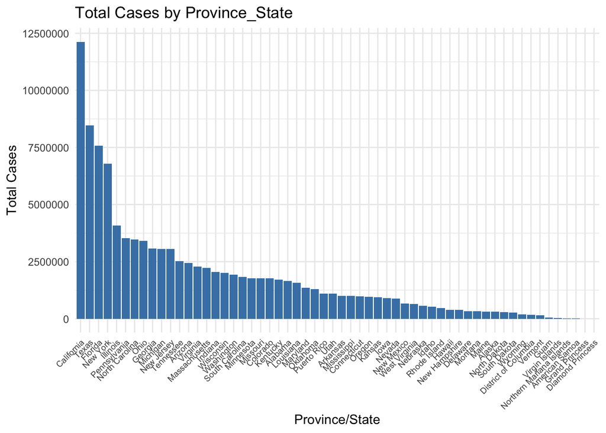

```r
ggplot(state_sum, aes(x = reorder(Province_State, -cases), y = cases)) +
  geom_bar(stat = "identity", fill = "steelblue") +
  theme_minimal() +
  labs(title = "Total Cases by Province_State",
       x = "Province/State",
       y = "Total Cases") +
  theme(legend.position = 'top', axis.text.x = element_text(angle=45, hjust=1, size=7))
```

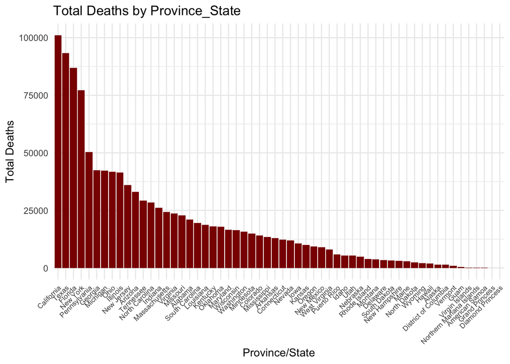

```r
ggplot(state_sum, aes(x = reorder(Province_State, -deaths), y = deaths)) +
  geom_bar(stat = "identity", fill = "darkred") +
  theme_minimal() +
  labs(title = "Total Deaths by Province_State",
       x = "Province/State",
       y = "Total Deaths") +
  theme(legend.position = 'top', axis.text.x = element_text(angle=45, hjust=1, size=7))
```

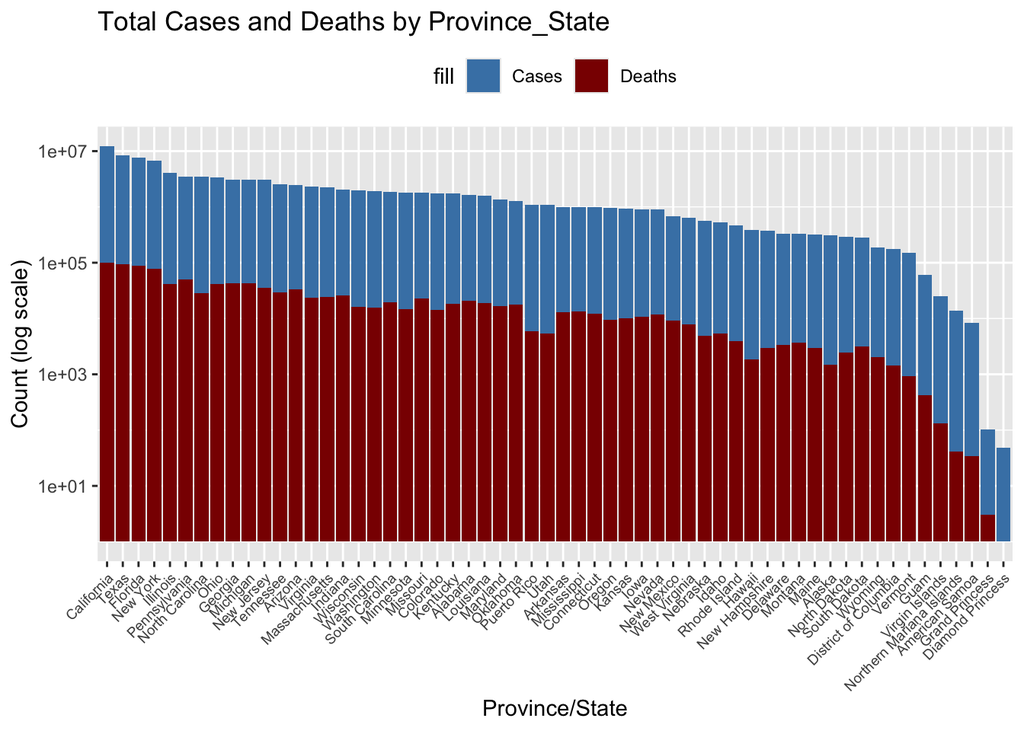

```r
ggplot(state_sum, aes(x = reorder(Province_State, -cases))) +
  geom_bar(aes(y = cases, fill = "Cases"), stat = "identity", position = "dodge") +
  geom_bar(aes(y = deaths, fill = "Deaths"), stat = "identity", position = "dodge") +
  scale_y_log10() +
  labs(title = "Total Cases and Deaths by Province_State",
       x = "Province/State",
       y = "Count (log scale)") +
  scale_fill_manual(values = c("Cases" = "steelblue", "Deaths" = "darkred")) +
  theme(legend.position = 'top', axis.text.x = element_text(angle=45, hjust=1, size=7))
```

The number of deaths for the Diamond Princess is 0, which causes issues when converting to a log10 scale. Therefore, if the values for cases or deaths are less than 1, they are adjusted to 1. Additionally, the population for the Diamond Princess is recorded as 0, but there are 49 cases; hence, if the population is zero, it is set to the number of cases.

### US Totals

```r
us_totals <- us_by_state %>%
              group_by(Country_Region, date) %>%
              summarize(cases = sum(cases),
                        deaths = sum(deaths),
                        population = sum(population)) %>%
              mutate(deaths_per_mill = deaths * 1000000 / population) %>%
              select(Country_Region, date, cases, deaths, deaths_per_mill, population) %>%
              ungroup() %>%
              arrange(Country_Region, date) %>%
              mutate(new_cases = cases - lag(cases),
                     new_deaths = deaths - lag(deaths))
us_totals
```

```
## # A tibble: 1,143 × 8
##    Country_Region date       cases deaths deaths_per_mill population new_cases
##    <chr>          <date>     <int>  <int>           <dbl>      <int>     <int>
##  1 US             2020-01-22     1      1         0.00300  332875137        NA
##  2 US             2020-01-23     1      1         0.00300  332875137         0
##  3 US             2020-01-24     2      1         0.00300  332875137         1
##  4 US             2020-01-25     2      1         0.00300  332875137         0
##  5 US             2020-01-26     5      1         0.00300  332875137         3
##  6 US             2020-01-27     5      1         0.00300  332875137         0
##  7 US             2020-01-28     5      1         0.00300  332875137         0
##  8 US             2020-01-29     6      1         0.00300  332875137         1
##  9 US             2020-01-30     6      1         0.00300  332875137         0
## 10 US             2020-01-31     8      1         0.00300  332875137         2
## # ℹ 1,133 more rows
## # ℹ 1 more variable: new_deaths <int>
```

```r
tail(us_totals %>% select(new_cases, new_deaths, everything()))
```

```
## # A tibble: 6 × 8
##   new_cases new_deaths Country_Region date          cases deaths deaths_per_mill
##       <int>      <int> <chr>          <date>        <int>  <int>           <dbl>
## 1      2147          7 US             2023-03-04   1.04e8 1.12e6           3371.
## 2     -3862        -38 US             2023-03-05   1.04e8 1.12e6           3371.
## 3      8564         47 US             2023-03-06   1.04e8 1.12e6           3371.
## 4     35371        335 US             2023-03-07   1.04e8 1.12e6           3372.
## 5     64861        730 US             2023-03-08   1.04e8 1.12e6           3374.
## 6     46931        590 US             2023-03-09   1.04e8 1.12e6           3376.
## # ℹ 1 more variable: population <int>
```

```r
# max(us_totals$date)
# max(us_totals$deaths)
# min(us_totals$deaths)
summary(us_totals)
```

```
##  Country_Region          date                cases               deaths
##  Length:1143        Min.   :2020-01-22   Min.   :        1   Min.   :      1
##  Class :character   1st Qu.:2020-11-02   1st Qu.:  9401880   1st Qu.: 232564
##  Mode  :character   Median :2021-08-15   Median : 36845902   Median : 618029
##                     Mean   :2021-08-15   Mean   : 47080800   Mean   : 624563
##                     3rd Qu.:2022-05-27   3rd Qu.: 84083678   3rd Qu.:1006626
##                     Max.   :2023-03-09   Max.   :103802702   Max.   :1123836
##
##  deaths_per_mill      population          new_cases         new_deaths
##  Min.   :   0.003   Min.   :332875137   Min.   :  -3862   Min.   :-253.0
##  1st Qu.: 698.652   1st Qu.:332875137   1st Qu.:  25993   1st Qu.: 324.0
##  Median :1856.639   Median :332875137   Median :  55970   Median : 706.5
##  Mean   :1876.268   Mean   :332875137   Mean   :  90896   Mean   : 984.1
##  3rd Qu.:3024.033   3rd Qu.:332875137   3rd Qu.: 112464   3rd Qu.:1415.0
##  Max.   :3376.149   Max.   :332875137   Max.   :1354508   Max.   :4375.0
##                                         NA's   :1         NA's   :1
```

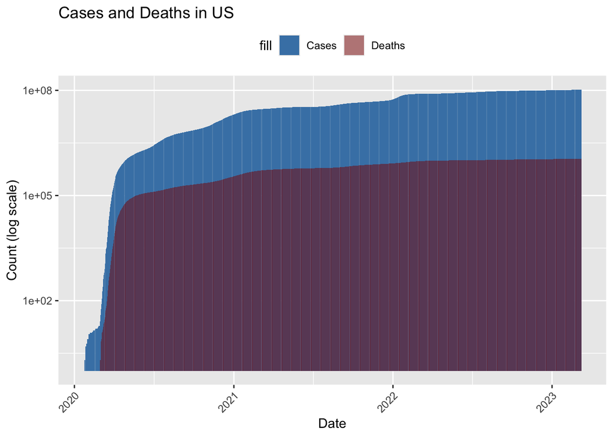

```r
us_totals_non0 <- us_totals %>%
                  filter(cases > 0)
ggplot(us_totals_non0, aes(x = date)) +
  geom_bar(aes(y = cases, fill = "Cases"), stat = "identity", position = "dodge") +
  geom_bar(aes(y = deaths, fill = "Deaths"), stat = "identity", position = "dodge", alpha = 0.5) +
  labs(title = "Cases and Deaths in US", x = "Date", y = "Count (log scale)") +
  scale_y_log10() +
  theme(axis.text.x = element_text(angle = 45, hjust = 1)) +
  scale_fill_manual(values = c("Cases" = "steelblue", "Deaths" = "darkred")) +
  theme(legend.position = 'top')
```

### Problematic Rows

```r
problematic_rows <- us_totals %>%
                    filter(is.nan(new_cases) | is.nan(new_deaths) |
                    is.na(new_cases) | is.na(new_deaths) |
                    is.infinite(new_cases) | is.infinite(new_deaths)) %>%
                    select(new_cases, new_deaths, everything())
print(problematic_rows)
```

```
## # A tibble: 1 × 8
##   new_cases new_deaths Country_Region date       cases deaths deaths_per_mill
##       <int>      <int> <chr>          <date>     <int>  <int>           <dbl>
## 1        NA         NA US             2020-01-22     1      1         0.00300
## # ℹ 1 more variable: population <int>
```

When calculating new cases and new deaths, the value from the previous day needs to be subtracted. However, since there is no prior day’s value for the first day, this results in NA. This is removed before continuing.

### New Cases, New Deaths, Percentage

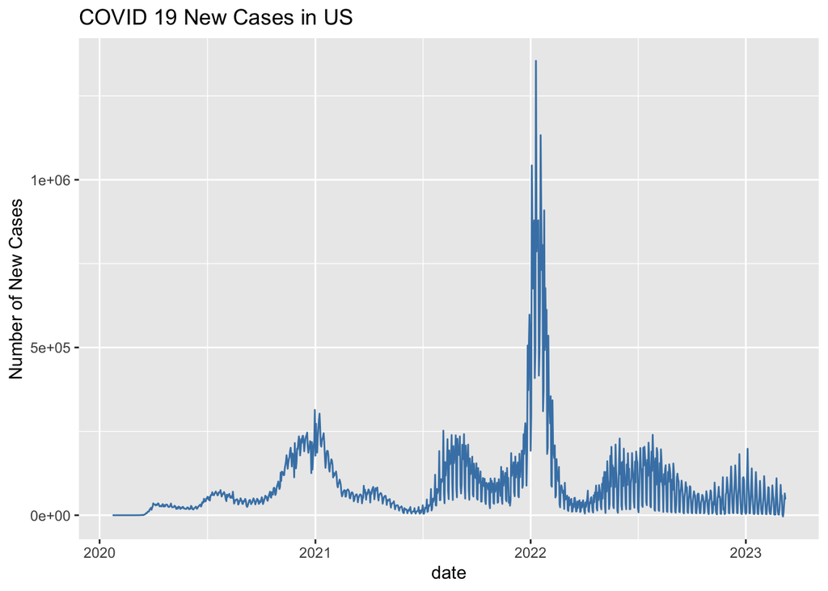

```r
us_totals_non0  <- us_totals_non0  %>%
                   filter(date != as.Date("2020-01-22")) %>%
                   mutate(death_perc = (new_deaths/new_cases)*100)

ggplot(us_totals_non0, aes(x = date, y = new_cases)) +
  geom_line(color = "steelblue") +
  labs(title = 'COVID 19 New Cases in US', y = 'Number of New Cases')
```

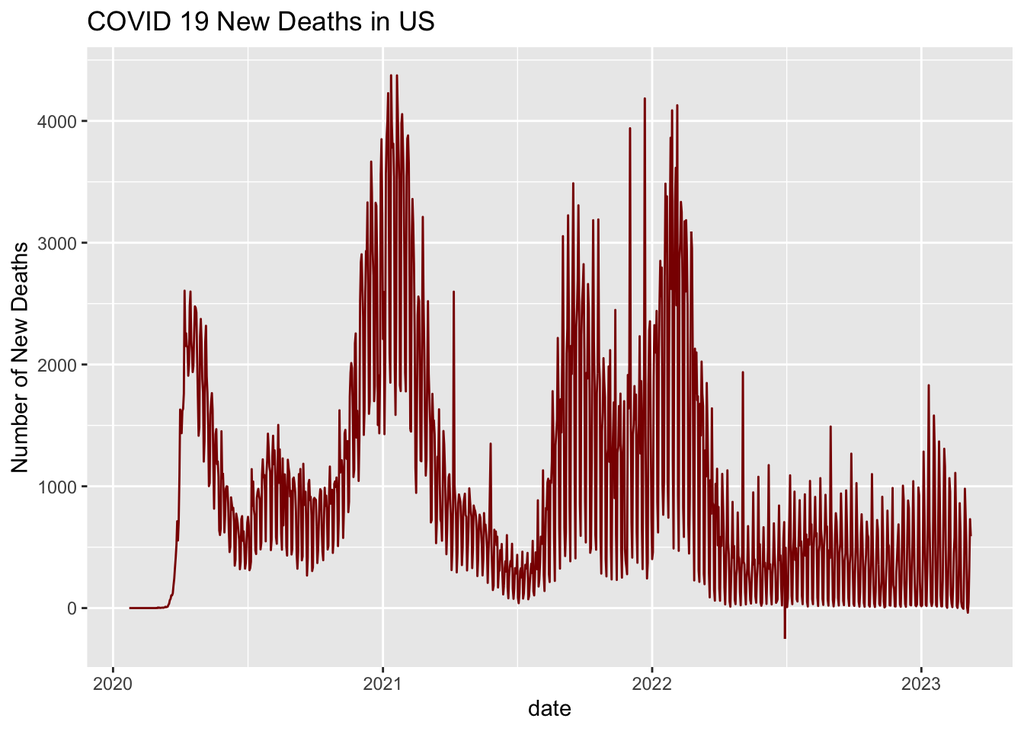

```r
ggplot(us_totals_non0, aes(x = date, y = new_deaths)) +
  geom_line(color = "darkred") +
  labs(title = 'COVID 19 New Deaths in US', y = 'Number of New Deaths')
```

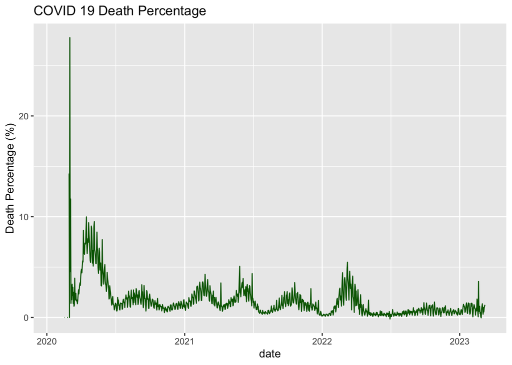

```r
ggplot(us_totals_non0, aes(x = date, y = death_perc)) +
  geom_line(color = "darkgreen") +
  labs(title = 'COVID 19 Death Percentage', y = 'Death Percentage (%)')
```

From the plots, it can be observed that new cases and deaths in winter are significantly higher compared to other seasons, indicating an increase in infections and fatalities during this period.

However, the peak mortality rates tend to occur more frequently during seasonal transitions, rather than in winter.

### New York

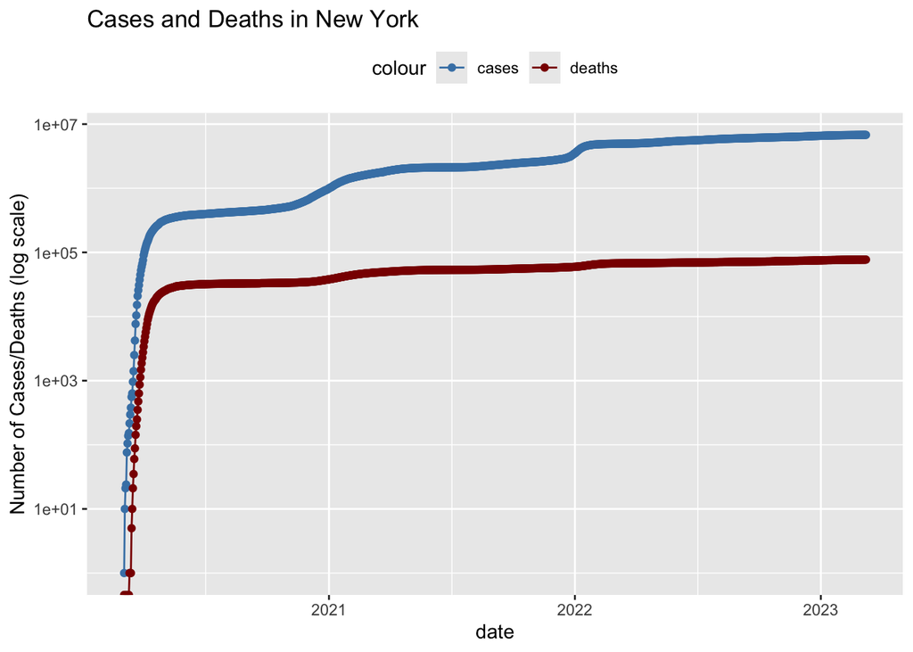

```r
state <- 'New York'

us_by_state %>%
filter(Province_State == state, cases > 0) %>%
ggplot(aes(x = date)) +
  geom_line(aes(y = cases, color = 'cases')) +
  geom_point(aes(y = cases, color = 'cases')) +
  geom_line(aes(y = deaths, color = 'deaths')) +
  geom_point(aes(y = deaths, color = 'deaths')) +
  scale_y_log10() +
  scale_color_manual(values = c('cases' = 'steelblue', 'deaths' = 'darkred')) +
  theme(legend.position = 'top') +
  labs(title = str_c('Cases and Deaths in ', state), y = 'Number of Cases/Deaths (log scale)')
```

# Model

### Linear Regression

```r
mod <- lm(deaths_per_thou ~ cases_per_thou, data = state_sum)
summary(mod)
```

```
##
## Call:
## lm(formula = deaths_per_thou ~ cases_per_thou, data = state_sum)
##
## Residuals:
##      Min       1Q   Median       3Q      Max
## -14.1119  -0.6076   0.1621   0.7119  15.0144
##
## Coefficients:
##                 Estimate Std. Error t value Pr(>|t|)
## (Intercept)    -1.742010   1.005988  -1.732   0.0888 .
## cases_per_thou  0.015854   0.002804   5.653 5.53e-07 ***
## ---
## Signif. codes:  0 '***' 0.001 '**' 0.01 '*' 0.05 '.' 0.1 ' ' 1
##
## Residual standard error: 2.889 on 56 degrees of freedom
## Multiple R-squared:  0.3633, Adjusted R-squared:  0.352
## F-statistic: 31.96 on 1 and 56 DF,  p-value: 5.531e-07
```

The intercept suggests that when cases_per_thou is 0, the predicted deaths_per_thou would be -1.742, but with a P-value of 0.0888, this is not statistically significant.

For each 1 increase in cases_per_thou, the predicted deaths_per_thou increases by 0.015854. With a P-value of 5.53e−07, this coefficient is highly statistically significant, indicating a strong positive impact of cases on deaths.

An R-squared value of 0.3633 means that the model explains 36.33% of the variance, indicating a moderate fit to the data. While the relationship is not perfectly linear, there is some correlation.

### Prediction

```r
state_pred <- state_sum %>%
              mutate(pred = predict(mod))
state_pred
```

```
## # A tibble: 58 × 13
##    Province_State   Country_Region date          cases deaths deaths_per_mill
##    <chr>            <chr>          <date>        <int>  <dbl>           <dbl>
##  1 Alabama          US             2023-03-09  1644533  21032           4289.
##  2 Alaska           US             2023-03-09   307655   1486           2005.
##  3 American Samoa   US             2023-03-09     8320     34            611.
##  4 Arizona          US             2023-03-09  2443514  33102           4548.
##  5 Arkansas         US             2023-03-09  1006883  13020           4314.
##  6 California       US             2023-03-09 12129699 101159           2560.
##  7 Colorado         US             2023-03-09  1764401  14181           2463.
##  8 Connecticut      US             2023-03-09   976657  12220           3427.
##  9 Delaware         US             2023-03-09   330793   3324           3414.
## 10 Diamond Princess US             2023-03-09       49      1            NaN
## # ℹ 48 more rows
## # ℹ 7 more variables: population <int>, new_cases <int>, new_deaths <int>,
## #   death_perc <dbl>, cases_per_thou <dbl>, deaths_per_thou <dbl>, pred <dbl>
```

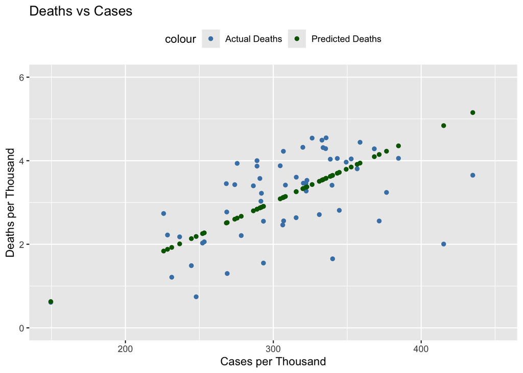

```r
ggplot(state_pred) +
  geom_point(aes(x = cases_per_thou, y = deaths_per_thou, color = "Actual Deaths")) +
  geom_point(aes(x = cases_per_thou, y = pred, color = "Predicted Deaths")) +
  coord_cartesian(xlim = c(150, 450), ylim = c(0, 6)) +
  labs(title = 'Deaths vs Cases', x = 'Cases per Thousand', y = 'Deaths per Thousand') +
  scale_color_manual(values = c("Actual Deaths" = "steelblue", "Predicted Deaths" = "darkgreen")) +
  theme(legend.position = "top")
```

# Brief Summary

- Global data records include 201 countries and 91 states/cities, with the highest recorded cases at 103,802,702 and the highest deaths at 1,123,836.
- The top ten countries with the highest total deaths are the US, Brazil, India, Russia, Mexico, UK, Peru, Italy, Germany, and France.
- New cases and deaths in winter are significantly higher compared to other seasons, indicating an increase in infections and fatalities during this period. However, the peak mortality rates tend to occur more frequently during seasonal transitions, rather than in winter.
- For every increase of 1 in cases per thousand, the predicted deaths per thousand increase by 0.015854. With a P-value of 5.53e−07, this shows a significant positive impact of case counts on death rates.
- In this model, potential sources of bias could include the exclusion of important variables, the influence of data outliers on the fit, or the use of an unsuitable model, as the relationship may not be purely linear.
- Further modeling approaches could be explored.